# Modeling Home Prices - Project 1

Seth Harrison

Last Compiled: Feb 18, 2021

**Directions: Answer all questions with complete sentences. When reporting numbers from computer output, use inline coding.**

# 1 Data

- Read the data from http://jse.amstat.org/datasets/homes76.dat.txt into an R object named `HP`. [1 pt.]
- Remove columns 1, 7, 10, 15, 16, 17, 18, and 19 from `HP` and store the result back in `HP`. [1 pt.]
- Name the columns in `HP` `price`, `size`, `lot`, `bath`, `bed`, `year`, `age`, `garage`, `status`, `active`, and `elem`, respectively. [1 pt.]
- Show the first six rows of `HP`. [1 pt.]

```r
library(readr)
HP <- read_tsv("http://jse.amstat.org/datasets/homes76.dat.txt")
HP <- HP[-c(1, 7, 10, 15, 16, 17, 18, 19)]
names(HP) <- c("price", "size", "lot", "bath", "bed", "year", "age", "garage", "status", "active", "elem")
head(HP)
```

```
# A tibble: 6 x 11
  price  size   lot  bath   bed  year   age garage status active elem
  <dbl> <dbl> <dbl> <dbl> <dbl> <dbl> <dbl>  <dbl> <chr>   <dbl> <chr>
1  388   2.18     4     3     4  1940  -3        0 sld         0 edison
2  450   2.05     5     3     4  1957  -1.3      2 sld         0 edison
3  386   2.11     5     2     4  1955  -1.5      2 sld         0 edison
4  350   1.44     6     1     2  1956  -1.4      1 act         1 adams
5  156.  1.8      1     2     4  1994   2.4      1 sld         0 adams
6  220   1.96     5     2     3  1940  -3        1 sld         0 adams
```

- Use the function `datatable` from the `DT` package to display the data from `HP`. [1 pt.]

```r
library(DT)
datatable(HP)
```

|  | price | size | lot | bath | bed | year | age | garage | status | active | elem |
| --- | --- | --- | --- | --- | --- | --- | --- | --- | --- | --- | --- |
| 1 | 388 | 2.18 | 4 | 3 | 4 | 1940 | -3 | 0 | sld | 0 | edison |
| 2 | 450 | 2.054 | 5 | 3 | 4 | 1957 | -1.3 | 2 | sld | 0 | edison |
| 3 | 386 | 2.112 | 5 | 2 | 4 | 1955 | -1.5 | 2 | sld | 0 | edison |
| 4 | 350 | 1.442 | 6 | 1 | 2 | 1956 | -1.4 | 1 | act | 1 | adams |
| 5 | 155.5 | 1.8 | 1 | 2 | 4 | 1994 | 2.4 | 1 | sld | 0 | adams |
| 6 | 220 | 1.965 | 5 | 2 | 3 | 1940 | -3 | 1 | sld | 0 | adams |
| 7 | 239.5 | 1.8 | 4 | 1.1 | 4 | 1958 | -1.2 | 1 | act | 1 | parker |
| 8 | 207 | 2.254 | 4 | 2 | 4 | 1961 | -0.9 | 2 | sld | 0 | parker |
| 9 | 269.9 | 1.922 | 4 | 2.1 | 4 | 1965 | -0.5 | 2 | act | 1 | parker |
| 10 | 238.8 | 1.92 | 5 | 2.1 | 3 | 1968 | -0.2 | 2 | sld | 0 | parker |

[output cut: 66 more lines]

- What are the units for `price` and `size`? [1 pt.]

# 2 Models

- Use the function `stepAIC` from the `MASS` package to create models using forward selection and backward elimination. Store the model from backward elimination in an object named `mod.be` and the model from forward selection in an object named `mod.fs`. [2 pts.]

```r
library(MASS)
modNull <- lm(price ~ 1, HP)
mod0 <- lm(price ~ ., HP)
mod.be <- stepAIC(mod0, direction = "backward")
```

```
Start:  AIC=591.14
price ~ size + lot + bath + bed + year + age + garage + status +
    active + elem


Step:  AIC=591.14
price ~ size + lot + bath + bed + year + age + garage + status +
    elem


Step:  AIC=591.14
price ~ size + lot + bath + bed + year + garage + status + elem

         Df Sum of Sq    RSS    AIC
- year    1       295 125846 589.32
- bath    1       436 125986 589.40
- garage  1      1338 126889 589.95
<none>                125551 591.14
- bed     1      3541 129092 591.25
- status  2     14277 139828 595.33
- size    1     11116 136666 595.59
- lot     1     16863 142414 598.72
- elem    5     72614 198165 615.83

Step:  AIC=589.32
price ~ size + lot + bath + bed + garage + status + elem

         Df Sum of Sq    RSS    AIC
- bath    1       658 126504 587.71
- garage  1      2066 127912 588.56
<none>                125846 589.32
- bed     1      4500 130346 589.99
- status  2     14556 140401 593.64
- size    1     11370 137216 593.89
- lot     1     16592 142437 596.73
- elem    5     78085 203930 616.00

Step:  AIC=587.71
price ~ size + lot + bed + garage + status + elem

         Df Sum of Sq    RSS    AIC
- garage  1      2432 128936 587.16
<none>                126504 587.71
- bed     1      4147 130651 588.17
- status  2     15172 141676 592.32
- lot     1     15997 142501 594.76
- size    1     16863 143367 595.22
- elem    5     80040 206544 614.97

Step:  AIC=587.16
price ~ size + lot + bed + status + elem

         Df Sum of Sq    RSS    AIC
<none>                128936 587.16
- bed     1      7689 136625 589.56
- status  2     22758 151694 595.52
- lot     1     18948 147883 595.58
- size    1     23305 152240 597.79
- elem    5     80234 209170 613.93
```

```r
mod.fs <- stepAIC(modNull, direction = "forward")
```

```
Start:  AIC=624.17
price ~ 1
```

- Which model (`mod.be` or `mod.fs`) do you believe is better and why? Consider the residuals, $R^2_a$, residual standard error, and AIC for both models when answering the question. [2 pts.]

```r
# Your code here
library(car)
summary(mod.be)
```

```
Call:
lm(formula = price ~ size + lot + bed + status + elem, data = HP)

Residuals:
    Min      1Q  Median      3Q     Max
-91.369 -29.241  -0.705  24.313 113.296

Coefficients:
            Estimate Std. Error t value Pr(>|t|)
(Intercept)  118.460     54.739   2.164  0.03414 *
size          90.210     26.319   3.428  0.00106 **
lot           10.754      3.480   3.091  0.00294 **
bed          -15.786      8.018  -1.969  0.05324 .
statuspen    -20.543     16.227  -1.266  0.21004
statussld    -43.291     12.890  -3.359  0.00131 **
elemcrest      1.261     33.763   0.037  0.97033
elemedge      11.903     28.145   0.423  0.67376
elemedison    85.616     29.470   2.905  0.00501 **
elemharris    58.506     29.680   1.971  0.05296 .
elemparker   -11.034     29.546  -0.373  0.71004
---
Signif. codes:  0 '***' 0.001 '**' 0.01 '*' 0.05 '.' 0.1 ' ' 1

Residual standard error: 44.54 on 65 degrees of freedom
Multiple R-squared:  0.5277,    Adjusted R-squared:  0.4551
F-statistic: 7.263 on 10 and 65 DF,  p-value: 1.393e-07
```

```r
summary(mod.fs)
```

```
Call:
lm(formula = price ~ 1, data = HP)

Residuals:
     Min       1Q   Median       3Q      Max
-130.295  -43.045   -9.795   50.955  164.205

Coefficients:
            Estimate Std. Error t value Pr(>|t|)
(Intercept)  285.795      6.921    41.3   <2e-16 ***
---
Signif. codes:  0 '***' 0.001 '**' 0.01 '*' 0.05 '.' 0.1 ' ' 1

Residual standard error: 60.33 on 75 degrees of freedom
```

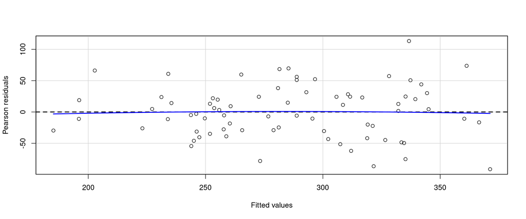

```r
residualPlot(mod.be)
```

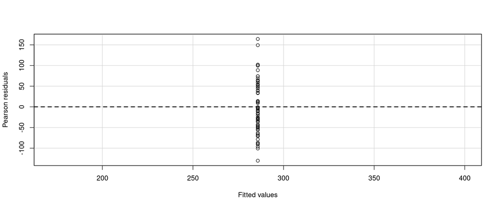

```r
residualPlot(mod.fs)
```

- Create a model and name it `mod1` that regresses `price` on all of the variables in `HP` with the exception of `status` and `year`. Produce a summary of `mod1` and graph the residuals using `residualPlots` from the `car` package. Based on your residual plots, what might you do to `mod1`? Report the adjusted $R^2$ value for `mod1`. [3 pts.]

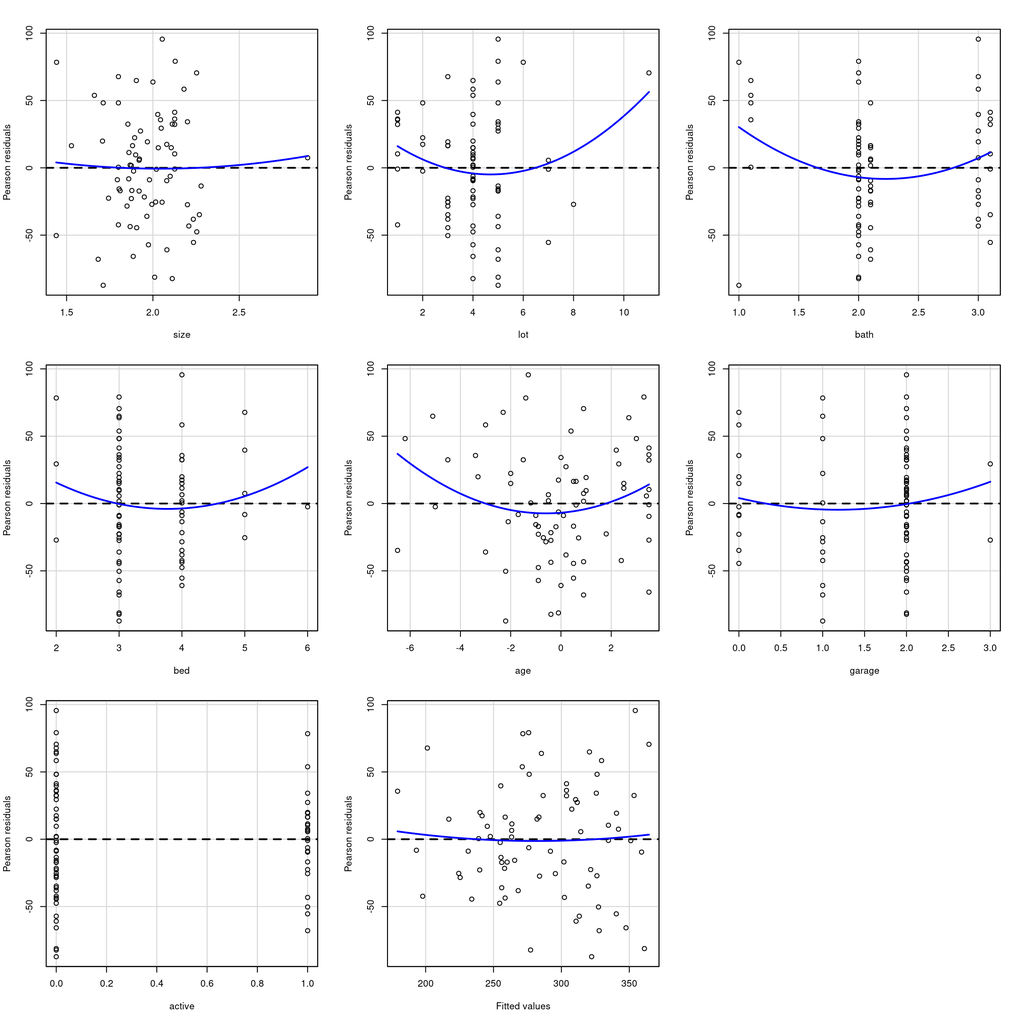

```
           Test stat Pr(>|Test stat|)
size          0.3033          0.76266
lot           1.9792          0.05223 .
bath          2.3757          0.02062 *
bed           1.0106          0.31614
age           2.3162          0.02387 *
garage        0.8135          0.41905
active       -2.0158          0.04816 *
Tukey test    0.3329          0.73922
---
Signif. codes:  0 '***' 0.001 '**' 0.01 '*' 0.05 '.' 0.1 ' ' 1
```

```r
mod1 <- lm(price ~ size + lot + bath + bed + age + garage + active + elem, HP)
residualPlots(mod1)
```

```r
summary(mod1)
```

```
Call:
lm(formula = price ~ size + lot + bath + bed + age + garage +
    active + elem, data = HP)

Residuals:
    Min      1Q  Median      3Q     Max
-87.265 -27.217  -0.222  30.125  95.583

Coefficients:
            Estimate Std. Error t value Pr(>|t|)
(Intercept)   88.144     57.780   1.526  0.13214
size          69.782     30.934   2.256  0.02756 *
lot           10.750      3.667   2.932  0.00469 **
bath           4.615     11.748   0.393  0.69575
bed          -12.459      9.120  -1.366  0.17676
age            1.626      3.324   0.489  0.62643
garage        10.053      9.261   1.086  0.28182
active        30.874     12.902   2.393  0.01971 *
elemcrest      4.809     34.067   0.141  0.88819
elemedge       7.466     29.050   0.257  0.79802
elemedison    87.195     30.810   2.830  0.00624 **
elemharris    53.786     30.629   1.756  0.08394 .
elemparker   -11.904     30.009  -0.397  0.69296
---
Signif. codes:  0 '***' 0.001 '**' 0.01 '*' 0.05 '.' 0.1 ' ' 1

Residual standard error: 45.11 on 63 degrees of freedom
Multiple R-squared:  0.5305,    Adjusted R-squared:  0.4411
F-statistic: 5.932 on 12 and 63 DF,  p-value: 8.906e-07
```

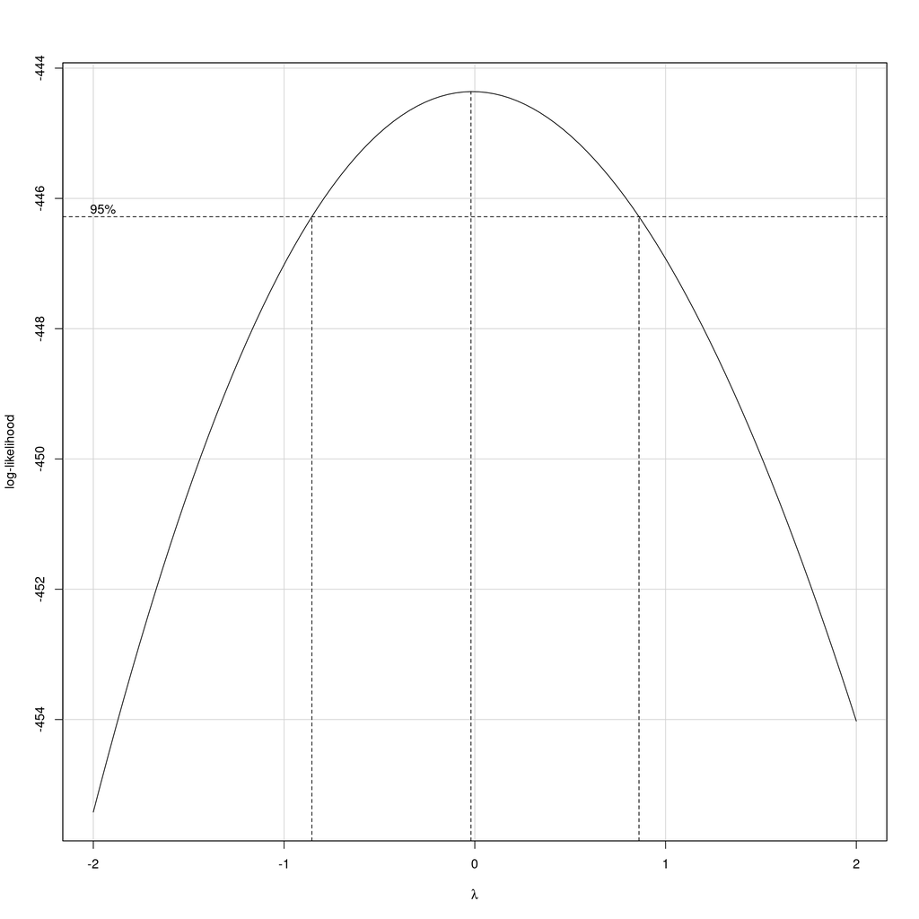

```r
boxCox(mod1)
```

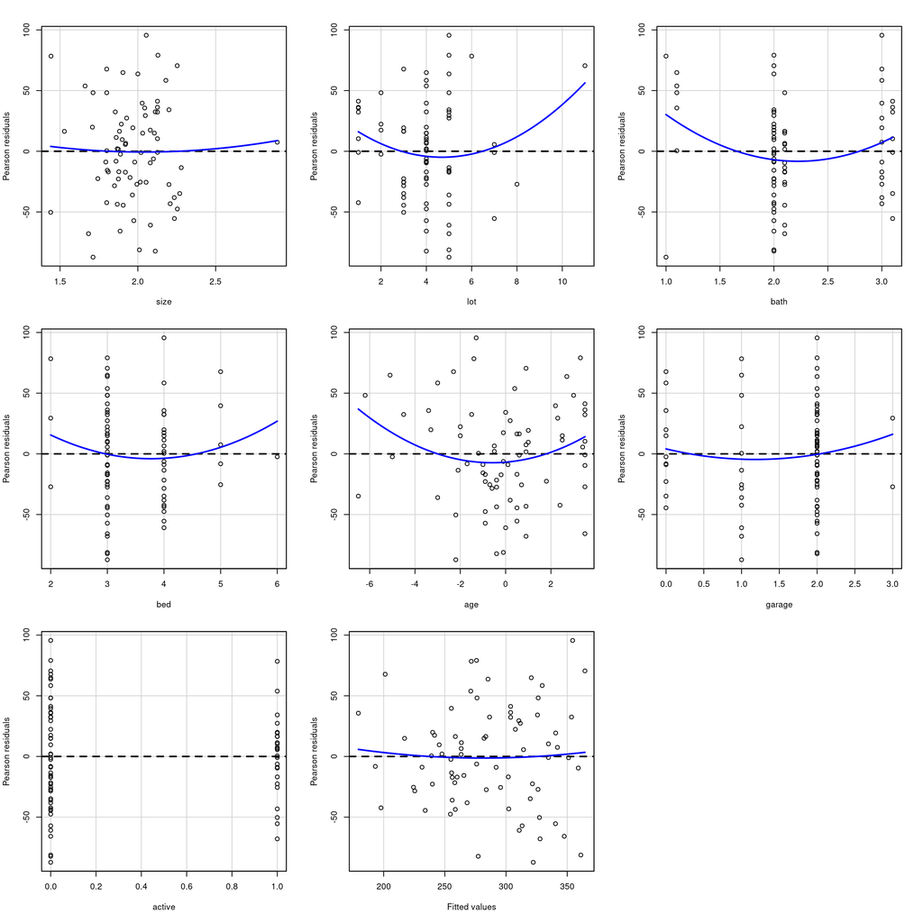

```
           Test stat Pr(>|Test stat|)
size          0.3033          0.76266
lot           1.9792          0.05223 .
bath          2.3757          0.02062 *
bed           1.0106          0.31614
age           2.3162          0.02387 *
garage        0.8135          0.41905
active       -2.0158          0.04816 *
Tukey test    0.3329          0.73922
---
Signif. codes:  0 '***' 0.001 '**' 0.01 '*' 0.05 '.' 0.1 ' ' 1
```

```r
mod1T <- lm(price ~ size + lot + bath + bed + age + garage + active + elem, HP)
residualPlots(mod1T)
```

**mod1 has an adjusted r-squared value of .4411.**

- Create a new model (`mod2`) by adding `bath:bed` and `age`$^2$ to `mod1`. Report the adjusted $R^2$ value for `mod2`. [2 pts.]

```r
mod2 <- lm(price ~ size + lot + bath + bed + age + garage + active + elem + bath:bed + I(age^2), HP)
summary(mod2)
```

```
Call:
lm(formula = price ~ size + lot + bath + bed + age + garage +
    active + elem + bath:bed + I(age^2), data = HP)

Residuals:
    Min      1Q  Median      3Q     Max
-83.284 -22.628  -0.066  27.790 111.323

Coefficients:
            Estimate Std. Error t value Pr(>|t|)
(Intercept) 308.7738   118.9553   2.596  0.01181 *
size         58.7689    29.2569   2.009  0.04900 *
lot          10.3619     3.5731   2.900  0.00518 **
bath        -98.7362    47.9507  -2.059  0.04376 *
bed         -77.4817    32.3252  -2.397  0.01961 *
age           3.7771     3.2371   1.167  0.24784
garage       10.6773     8.7030   1.227  0.22460
active       30.3572    12.2685   2.474  0.01614 *
elemcrest    20.0071    32.4456   0.617  0.53977
elemedge     28.8890    28.2176   1.024  0.30998
elemedison   88.1039    29.7429   2.962  0.00435 **
elemharris   69.1235    30.3032   2.281  0.02605 *
elemparker   14.9554    30.7470   0.486  0.62842
I(age^2)      1.8236     0.7571   2.409  0.01905 *
bath:bed     29.6573    13.6582   2.171  0.03380 *
---
Signif. codes:  0 '***' 0.001 '**' 0.01 '*' 0.05 '.' 0.1 ' ' 1

Residual standard error: 42.37 on 61 degrees of freedom
Multiple R-squared:  0.5989,    Adjusted R-squared:  0.5068
F-statistic: 6.505 on 14 and 61 DF,  p-value: 8.906e-08
```

**The new model has an adjusted $R^2$ value of .5068**

- Create a new model (`mod3`) by using only `edison` and `harris` from `elem` from `mod2`. Hint: use `I()`. Your estimated coefficients should agree with those in the [article](https://www.tandfonline.com/doi/full/10.1080/10691898.2008.11889569). Conduct a nested F-test (`anova(mod3, mod2`)). Does your p-value agree with the one presented in the article? Interpret this test. Report the adjusted $R^2$ value for `mod3`. [4 pts.]

```r
mod3 <- lm(price ~ size + lot + bath + bed + age + garage + active + bath:bed + I(age^2) + I(elem == "edison") + I(elem == "harris"), HP)
anova(mod3, mod2)
```

```
Analysis of Variance Table

Model 1: price ~ size + lot + bath + bed + age + garage + active + bath:bed +
    I(age^2) + I(elem == "edison") + I(elem == "harris")
Model 2: price ~ size + lot + bath + bed + age + garage + active + elem +
    bath:bed + I(age^2)
  Res.Df    RSS Df Sum of Sq      F Pr(>F)
1     64 112395
2     61 109506  3    2889.6 0.5365  0.659
```

- Compute the training mean square prediction error for all five of the models. Which model has the smallest training mean square prediction error? Do you think this model will also have the smallest test mean square prediction error? [3 pts.]

```r
mean(summary(mod.fs)$residuals^2)
```

```
[1] 3592.138
```

```r
mean(summary(mod.be)$residuals^2)
```

```
[1] 1696.523
```

```r
mean(summary(mod1)$residuals^2)
```

```
[1] 1686.554
```

```r
mean(summary(mod2)$residuals^2)
```

```
[1] 1440.867
```

```r
mean(summary(mod3)$residuals^2)
```

```
[1] 1478.887
```

**Model number 2 has the smallest training MSE and though model 3 would likely have the lowest test MSE because it is a slightly modified version of mod2 to reduce error.**

# 3 Predictions

- Use `mod3` to create a 95% prediction interval for a home with the following features: 1879 feet, lot size category 4, two and a half baths, three bedrooms, built in 1975, two-car garage, and near Parker Elementary School. [3 pts.]

```r
predict(mod3, newdata = data.frame(age = 0.5, size = 1.879, lot=4, bath= 2.1, bed = 3, year = 1975, garage = 2, elem = "parker", active = 1), interval = "prediction", level = .95)
```

```
       fit      lwr      upr
1 283.0415 197.0626 369.0205
```

- **EXTRA CREDIT:** Run the following code:

```r
library(effects)
plot(allEffects(mod2))
plot(effect("bath*bed", mod2))
plot(effect("bath*bed", mod2, xlevels=list(bed=2:5)))
plot(effect("bath*bed", mod2, xlevels=list(bath=1:3)))
```

Explain what each set of graphs is showing.